# act_report

### We Rate Dogs review

In this report, we have a chance to look visually at our dataset and have some insights about it. We have created a finalized list of the dataframe that has all the dogs in it, we have checked the top 10 favorite counts and top 10 retweet counts and created a new list for both of them. Below you can see the number of favorites count and retweet count for the top 10 dogs in a barplot.

As all dogs look amazing, we have found that the most popular dogs in We Share Dogs dataset were the Golden retreiver which comes in the first place, the Lebrador retreivers which is the second most popular, then the Chiuawas. We have found that 9% to 10% of dog owners have Golden retreivers, which is considered high for one specific bread.

We have also found that pupper dog stage is the most popular stage between all dog stages.

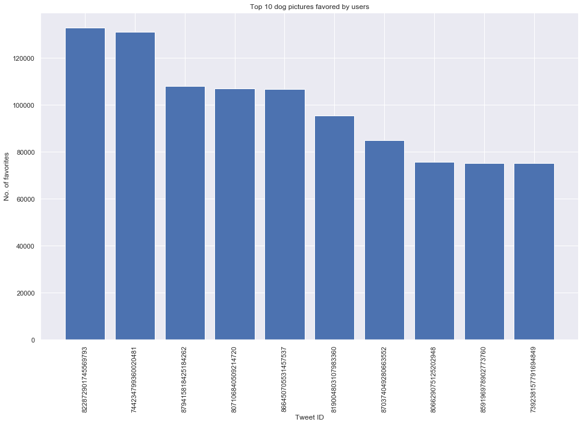

As we can see below, the highest retweet count a dog received was about 79000+ retweeted

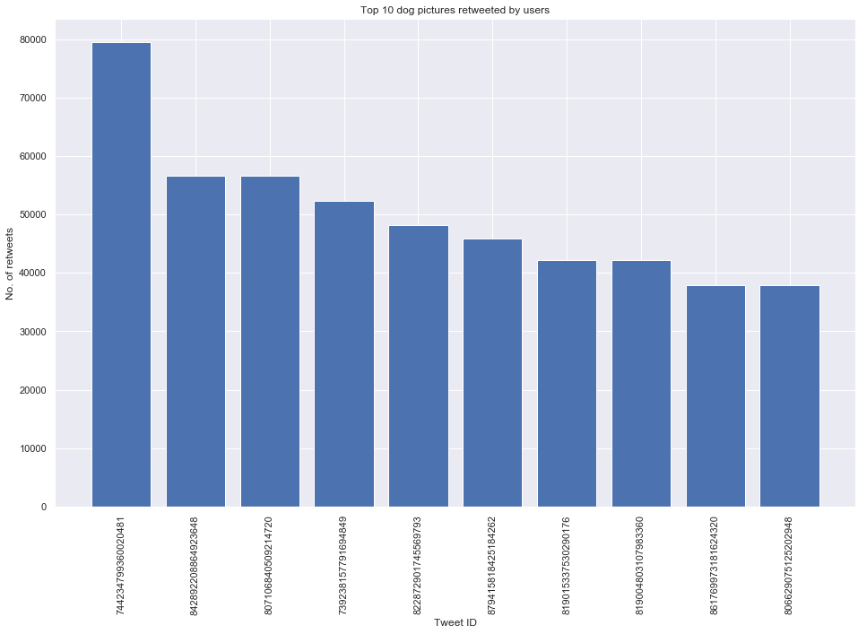

Below we can see together the photos of the top 10 dogs who are most favorited in all the dataset, we have included the text for them as a title and attached the number of favorites they got and their tweet ID on the axis.

You can always use the short link in their text to see their pics or check their tweet using the tweet ID on each pic to see their their current retweet count and favorite count.

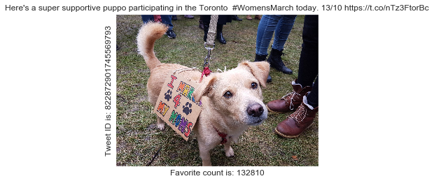

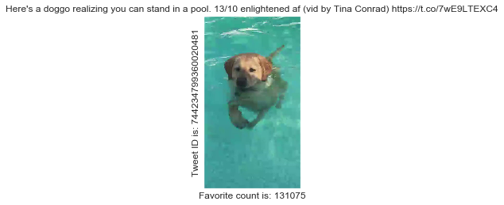

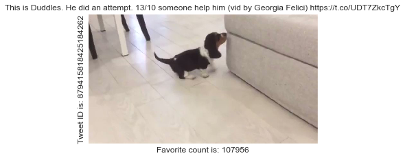

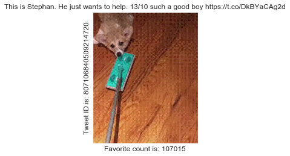

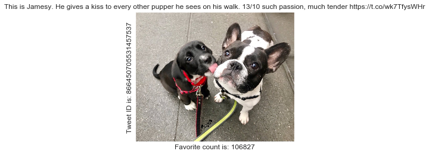

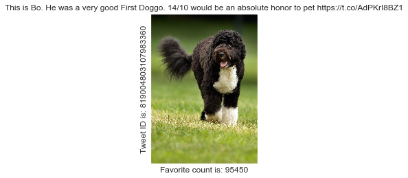

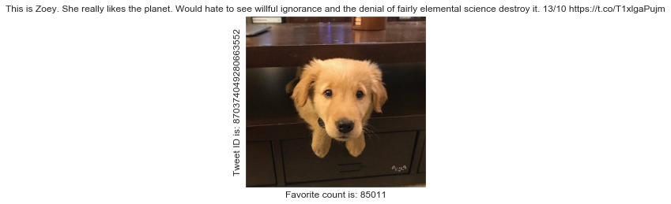

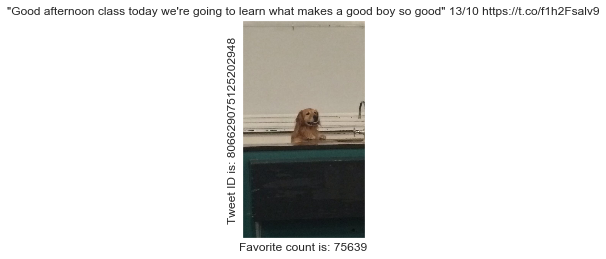

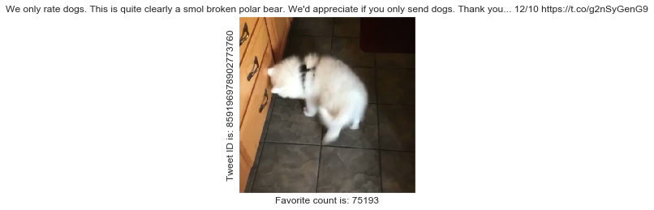

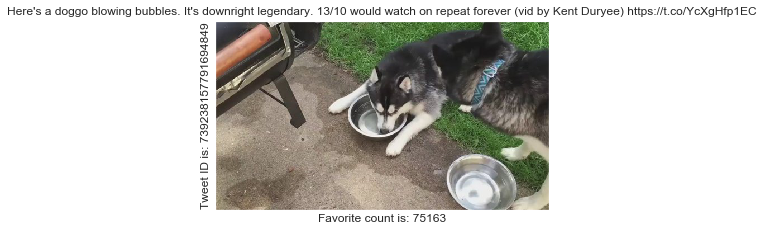